# Week 3 Tasks Solutions

```r
library(tidyverse)
library(tidymodels)
library(moderndive)
library(gapminder)
library(skimr)
library(mvtnorm)
library(gridExtra)
library(ISLR)
```

# Tasks

1. Examine the relationship between teaching score and age in the `evals` data set. What is the value of the correlation coefficient? How would you interpret this verbally? Finally, produce a scatterplot of teaching score and age.

```r
evals.age <- evals |>
  select(score, age)
evals.age |>
  get_correlation(formula = score ~ age)
```

```
# A tibble: 1 × 1
     cor
   <dbl>
1 -0.107
```

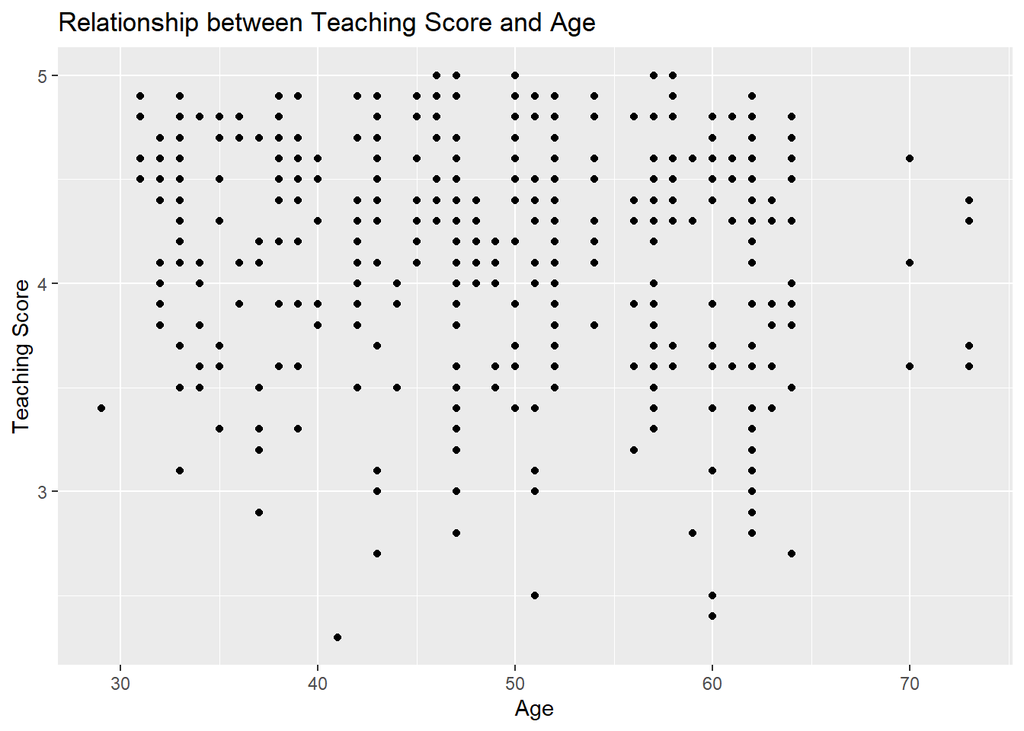

```r
ggplot(evals.age, aes(x = age, y = score)) +
  geom_point() +
  labs(x = "Age", y = "Teaching Score",
       title = "Relationship between Teaching Score and Age")
```

2. Perform a formal analysis of the relationship between teaching score and age by fitting a simple linear regression model. Superimpose your best-fitting line onto your scatterplot from Task 1.

```r
evals.age <- evals |>
  select(score, age)
model <- linear_reg() |> fit(score ~ age, data = evals.age)
model$fit
```

```
Call:
stats::lm(formula = score ~ age, data = data)

Coefficients:
(Intercept)          age
   4.461932    -0.005938
```

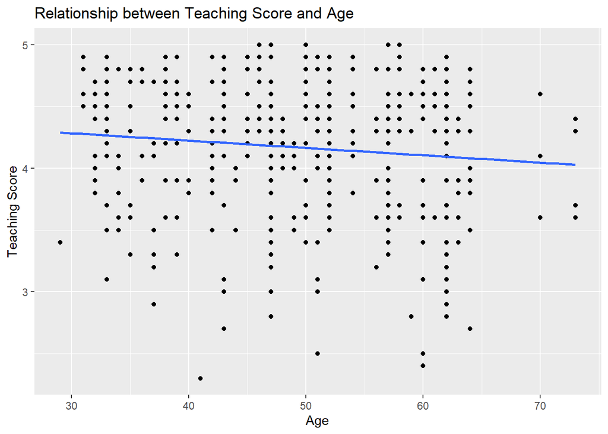

```r
ggplot(evals.age, aes(x = age, y = score)) +
  geom_point() +
  labs(x = "Age", y = "Teaching Score",
       title = "Relationship between Teaching Score and Age") +
  geom_smooth(method = "lm", se = FALSE)
```

3. Assess the model assumptions from Task 2 by plotting the residuals against the explanatory variable and fitted values, respectively. Also, plot a histogram of the residuals to assess whether they are normally distributed.

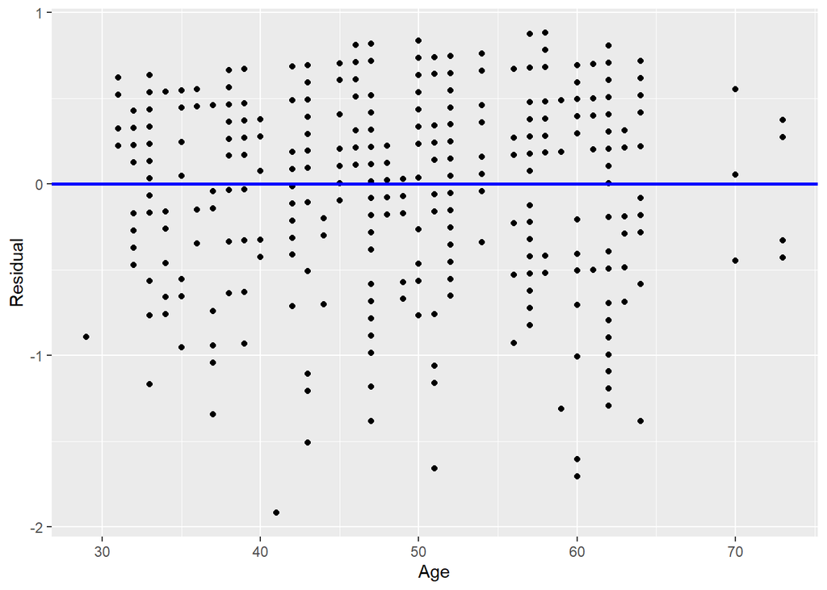

```r
evals.age <- evals |>
  select(score, age)
model <- linear_reg() |> fit(score ~ age, data = evals.age)
regression.points <- get_regression_points(model$fit)
ggplot(regression.points, aes(x = age, y = residual)) +
  geom_point() +
  labs(x = "Age", y = "Residual") +
  geom_hline(yintercept = 0, col = "blue", size = 1)
```

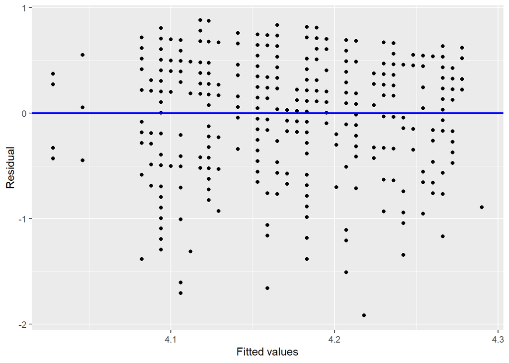

```r
ggplot(regression.points, aes(x = score_hat, y = residual)) +
  geom_point() +
  labs(x = "Fitted values", y = "Residual") +
  geom_hline(yintercept = 0, col = "blue", size = 1)
```

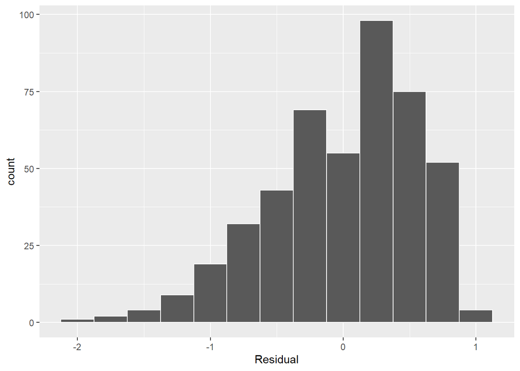

```r
ggplot(regression.points, aes(x = residual)) +
  geom_histogram(binwidth = 0.25, color = "white") +
  labs(x = "Residual")
```

4. Perform the same analysis we did on life expectancy from the `gapminder` data set in 2007. However, subset the data for the year 1997. Are there any differences in the results across this 10 year period?

   ```r
   gapminder1997 <- gapminder |>
     filter(year == 1997) |>
     select(country, continent, lifeExp)

   lifeExp.continent <- gapminder1997 |>
     summarize(median = median(lifeExp), mean = mean(lifeExp),.by=continent)
   lifeExp.continent
   ```

   ```
   # A tibble: 5 × 3
     continent median  mean
     <fct>      <dbl> <dbl>
   1 Asia        70.3  68.0
   2 Europe      76.1  75.5
   3 Africa      52.8  53.6
   4 Americas    72.1  71.2
   5 Oceania     78.2  78.2
   ```

   ```r
   lifeExp.model <- linear_reg() |> fit(lifeExp ~ continent, data = gapminder1997)
   lifeExp.model
   ```

   ```
   parsnip model object


   Call:
   stats::lm(formula = lifeExp ~ continent, data = data)

   Coefficients:
         (Intercept)  continentAmericas      continentAsia    continentEurope
               53.60              17.55              14.42              21.91
    continentOceania
               24.59
   ```

5. Return to the `Credit` data set and fit a multiple regression model with `Balance` as the outcome variable, and `Income` and `Age` as the explanatory variables, respectively. Assess the assumptions of the multiple regression model.

```r
Cred <- Credit |>
  select(Balance, Income, Age)

Cred |>
  skim()
```

Data summary

| Name | Cred |
| --- | --- |
| Number of rows | 400 |
| Number of columns | 3 |
| _______________________ |  |
| Column type frequency: |  |
| numeric | 3 |
| ________________________ |  |
| Group variables | None |

**Variable type: numeric**

| skim_variable | n_missing | complete_rate | mean | sd | p0 | p25 | p50 | p75 | p100 | hist |
| --- | --- | --- | --- | --- | --- | --- | --- | --- | --- | --- |
| Balance | 0 | 1 | 520.02 | 459.76 | 0.00 | 68.75 | 459.50 | 863.00 | 1999.00 | ▇▅▃▂▁ |
| Income | 0 | 1 | 45.22 | 35.24 | 10.35 | 21.01 | 33.12 | 57.47 | 186.63 | ▇▂▁▁▁ |
| Age | 0 | 1 | 55.67 | 17.25 | 23.00 | 41.75 | 56.00 | 70.00 | 98.00 | ▆▇▇▇▁ |

```r
Cred |>
  cor()
```

```
            Balance    Income         Age
Balance 1.000000000 0.4636565 0.001835119
Income  0.463656457 1.0000000 0.175338403
Age     0.001835119 0.1753384 1.000000000
```

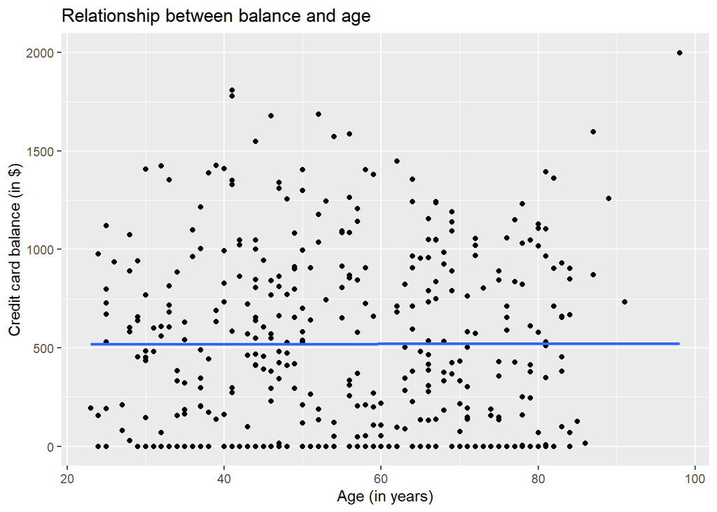

```r
ggplot(Cred, aes(x = Age, y = Balance)) +
  geom_point() +
  labs(x = "Age (in years)", y = "Credit card balance (in $)",
       title = "Relationship between balance and age") +
  geom_smooth(method = "lm", se = FALSE)
```

```r
Balance.model <- linear_reg() |> fit(Balance ~ Age + Income, data = Cred)
tidy(Balance.model)
```

```
# A tibble: 3 × 5
  term        estimate std.error statistic  p.value
  <chr>          <dbl>     <dbl>     <dbl>    <dbl>
1 (Intercept)   360.      70.4        5.11 4.97e- 7
2 Age            -2.19     1.20      -1.82 6.91e- 2
3 Income          6.24     0.587     10.6  2.20e-23
```

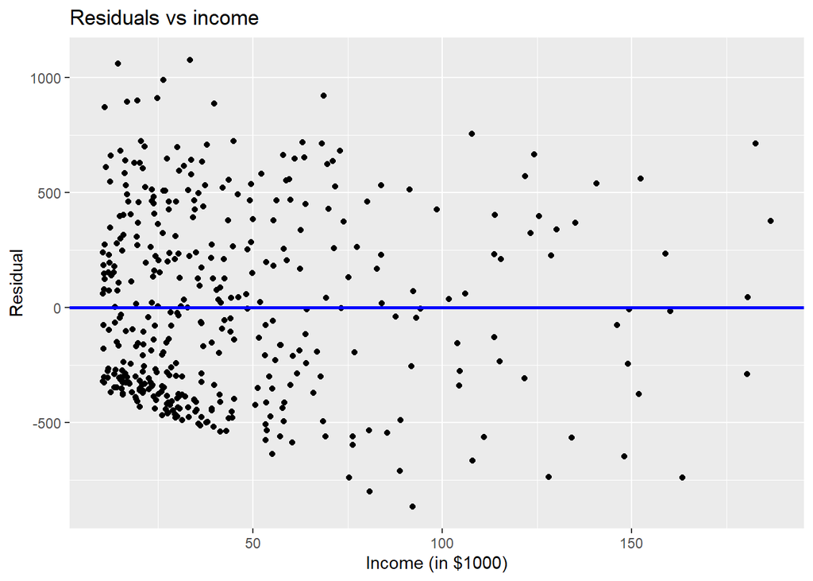

```r
regression.points <- get_regression_points(Balance.model$fit)

ggplot(regression.points, aes(x = Income, y = residual)) +
  geom_point() +
  labs(x = "Income (in $1000)", y = "Residual", title = "Residuals vs income")  +
  geom_hline(yintercept = 0, col = "blue", size = 1)
```

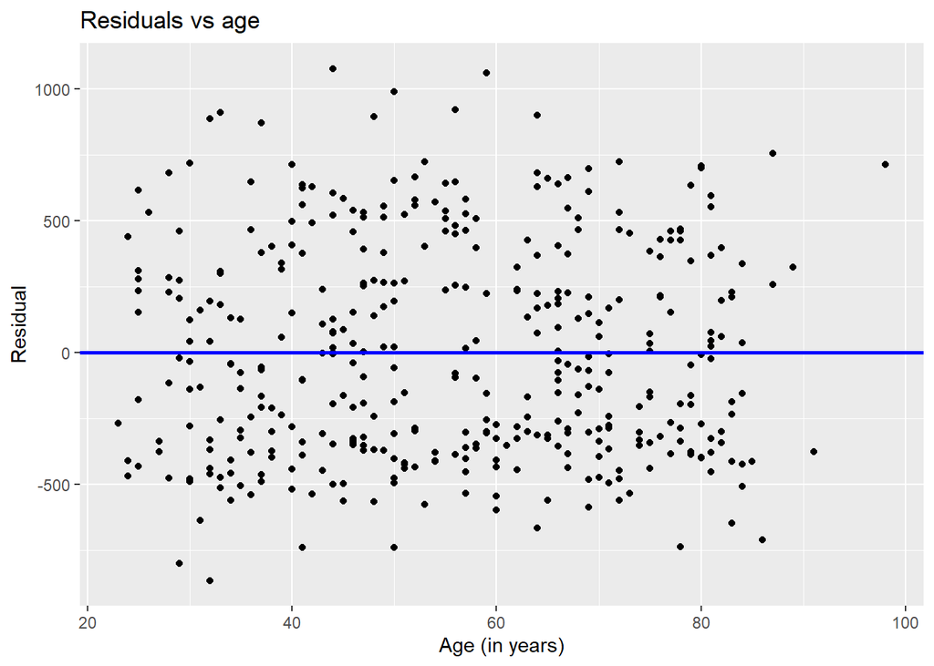

```r
ggplot(regression.points, aes(x = Age, y = residual)) +
  geom_point() +
  labs(x = "Age (in years)", y = "Residual", title = "Residuals vs age")  +
  geom_hline(yintercept = 0, col = "blue", size = 1)
```

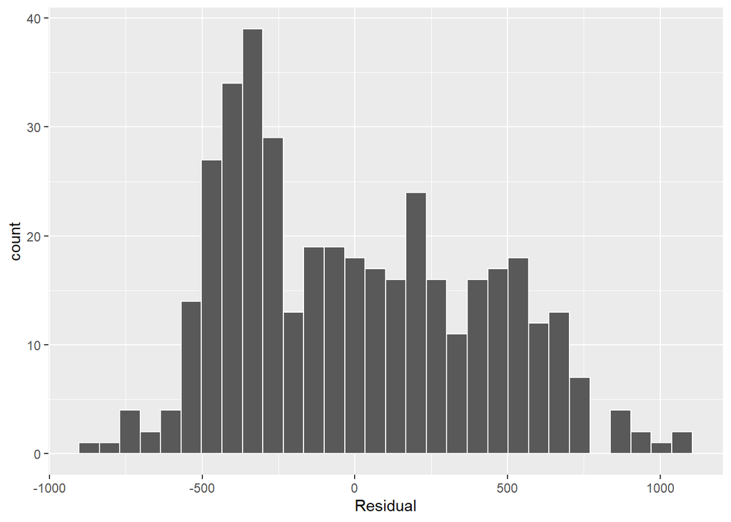

```r
ggplot(regression.points, aes(x = residual)) +
  geom_histogram(color = "white") +
  labs(x = "Residual")
```